# Kashyap_HW6

Madhuri

2022-11-27

## Homework 6

```r
library(tidymodels)
library(tidyverse)
library(ggplot2)
library(janitor)
library(corrplot)
library(rpart.plot)
library(randomForest)
library(vip)
library(caret)
library(broom)
library(boot)

pokemon <- read.csv("Pokemon.csv")
```

### Exercise 1

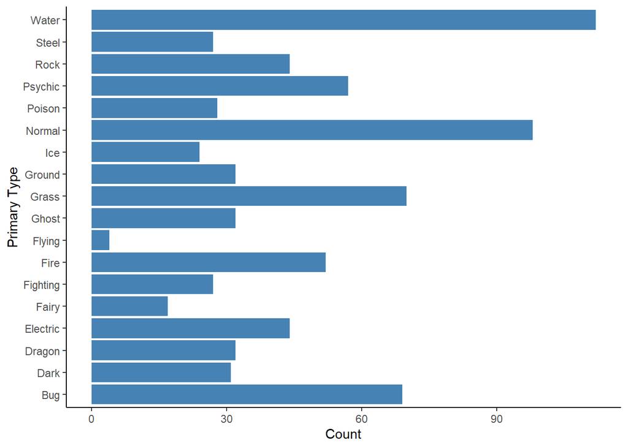

```r
pokemon_clean <- as_tibble(pokemon) %>%
  clean_names()

#visualizing types
ggplot(pokemon_clean, aes(x = type_1)) +
  geom_bar(stat = "count", fill = "steelblue") +
  theme_classic() +
  coord_flip() +
  xlab("Primary Type") +
  ylab("Count")
```

```r
#filtering data
df_filtered <- filter(pokemon_clean, type_1 == "Bug" | type_1 == "Fire" | type_1 == "Grass"
                      | type_1 == "Normal" | type_1 == "Water" | type_1 == "Psychic")

#checking new dataframe
summary(factor(df_filtered$type_1))
```

```
##     Bug    Fire   Grass  Normal Psychic   Water
##      69      52      70      98      57     112
```

```r
#converting to factors
df_filtered$type_1 <- as.factor(df_filtered$type_1)
df_filtered$legendary <- as.factor(df_filtered$legendary)
df_filtered$generation <- as.factor(df_filtered$generation)

#splitting data
set.seed(1212)
df_split <- initial_split(df_filtered, strata = "type_1")

df_train <- training(df_split)
df_test <- testing(df_split)

#v-fold
df_fold <- vfold_cv(df_train, v = 5, strata = "type_1")

#recipe
simple_rec1 <- recipe(type_1 ~ legendary + generation + sp_atk + attack + speed + defense +
                        hp + sp_def, data = df_train)

pokemon_recipe <- simple_rec1 %>%
  step_dummy(legendary) %>%
  step_dummy(generation) %>%
  step_center(all_numeric_predictors()) %>%
  step_scale(all_numeric_predictors())
pokemon_recipe
```

```
## Recipe
##
## Inputs:
##
##       role #variables
##    outcome          1
##  predictor          8
##
## Operations:
##
## Dummy variables from legendary
## Dummy variables from generation
## Centering for all_numeric_predictors()
## Scaling for all_numeric_predictors()
```

### Exercise 2

```r
summary(df_train)
```

```
##        x             name               type_1      type_2
##  Min.   :  1.0   Length:341         Bug    :51   Length:341
##  1st Qu.:150.0   Class :character   Fire   :39   Class :character
##  Median :287.0   Mode  :character   Grass  :52   Mode  :character
##  Mean   :319.7                      Normal :73
##  3rd Qu.:498.0                      Psychic:42
##  Max.   :721.0                      Water  :84
##      total           hp             attack          defense
##  Min.   :180   Min.   : 20.00   Min.   :  5.00   Min.   :  5.0
##  1st Qu.:320   1st Qu.: 50.00   1st Qu.: 52.00   1st Qu.: 50.0
##  Median :424   Median : 65.00   Median : 70.00   Median : 65.0
##  Mean   :424   Mean   : 70.03   Mean   : 74.56   Mean   : 67.6
##  3rd Qu.:500   3rd Qu.: 80.00   3rd Qu.: 95.00   3rd Qu.: 84.0
##  Max.   :780   Max.   :255.00   Max.   :190.00   Max.   :180.0
##      sp_atk           sp_def           speed        generation legendary
##  Min.   : 10.00   Min.   : 20.00   Min.   :  5.00   1:87       False:319
##  1st Qu.: 50.00   1st Qu.: 50.00   1st Qu.: 50.00   2:55       True : 22
##  Median : 65.00   Median : 65.00   Median : 65.00   3:63
##  Mean   : 72.92   Mean   : 69.73   Mean   : 69.16   4:48
##  3rd Qu.: 91.00   3rd Qu.: 85.00   3rd Qu.: 90.00   5:67
##  Max.   :194.00   Max.   :160.00   Max.   :180.00   6:21
```

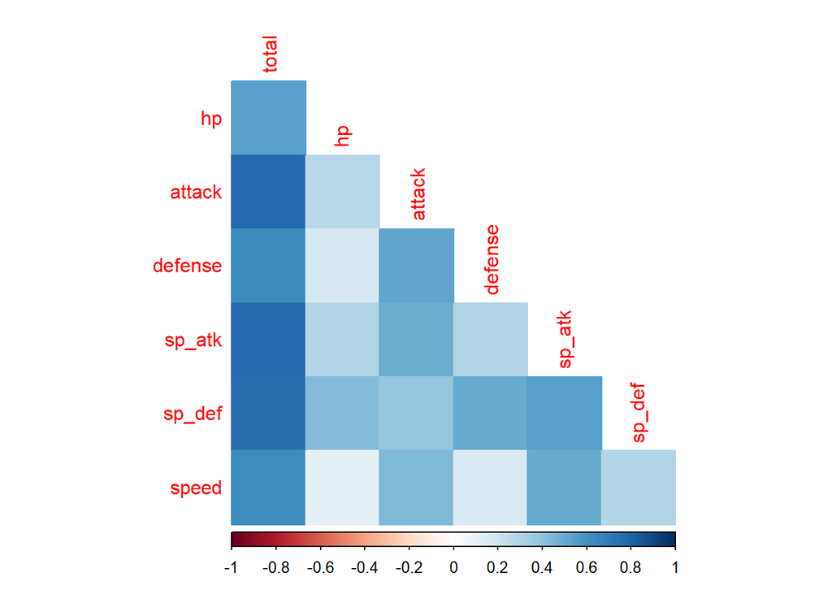

```r
mat <- select(df_train,total:speed)
mat %>%
  cor() %>%
  corrplot(type = "lower", diag = F, method = 'color')
```

We see that there are no negative correlations which fits with intuition. We also see that the total score is strongly correlated with special attack, and defense, and attack which we would expect as these scores contribute directly to the total score.

### Exercise 3

```r
#model
tree_spec <- decision_tree() %>%
  set_engine("rpart") %>%
  set_mode("classification")

#workflow
tree_wf <- workflow() %>%
  add_model(tree_spec %>% set_args(cost_complexity = tune())) %>%
  add_formula(type_1 ~ legendary + generation + sp_atk + attack + speed +
                defense + hp + sp_def)

#tuning cost_complexity
set.seed(1212)

param_grid <- grid_regular(cost_complexity(range = c(-3, -1)), levels = 10)

tune_res <- tune_grid(
  tree_wf,
  resamples = df_fold,
  grid = param_grid,
  metrics = metric_set(roc_auc)
)
tune_res
```

```
## # Tuning results
## # 5-fold cross-validation using stratification
## # A tibble: 5 × 4
##   splits           id    .metrics          .notes
##   <list>           <chr> <list>            <list>
## 1 <split [270/71]> Fold1 <tibble [10 × 5]> <tibble [0 × 3]>
## 2 <split [271/70]> Fold2 <tibble [10 × 5]> <tibble [0 × 3]>
## 3 <split [273/68]> Fold3 <tibble [10 × 5]> <tibble [0 × 3]>
## 4 <split [274/67]> Fold4 <tibble [10 × 5]> <tibble [0 × 3]>
## 5 <split [276/65]> Fold5 <tibble [10 × 5]> <tibble [0 × 3]>
```

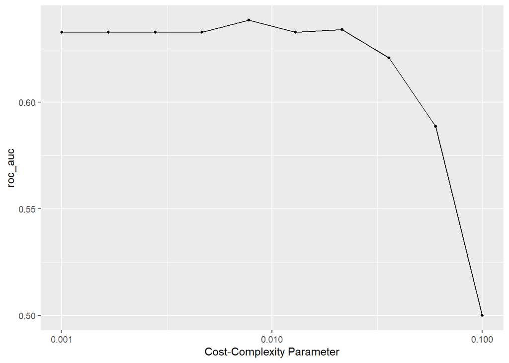

```r
#visualizing
autoplot(tune_res)
```

We see that smaller complexity penalties yield higher model ROC AUC values, and these taper off severely once penalty values are greater than 0.05. Single decision trees therefore perform better with smaller complexity penalty values.

### Exercise 4

```r
tune_res %>%
  collect_metrics() %>%
  arrange(mean)
```

```
## # A tibble: 10 × 7
##    cost_complexity .metric .estimator  mean     n std_err .config
##              <dbl> <chr>   <chr>      <dbl> <int>   <dbl> <chr>
##  1         0.1     roc_auc hand_till  0.5       5 0       Preprocessor1_Model10
##  2         0.0599  roc_auc hand_till  0.589     5 0.0265  Preprocessor1_Model09
##  3         0.0359  roc_auc hand_till  0.621     5 0.00980 Preprocessor1_Model08
##  4         0.001   roc_auc hand_till  0.633     5 0.0110  Preprocessor1_Model01
##  5         0.00167 roc_auc hand_till  0.633     5 0.0110  Preprocessor1_Model02
##  6         0.00278 roc_auc hand_till  0.633     5 0.0110  Preprocessor1_Model03
##  7         0.00464 roc_auc hand_till  0.633     5 0.0110  Preprocessor1_Model04
##  8         0.0129  roc_auc hand_till  0.633     5 0.00958 Preprocessor1_Model06
##  9         0.0215  roc_auc hand_till  0.634     5 0.00953 Preprocessor1_Model07
## 10         0.00774 roc_auc hand_till  0.638     5 0.00997 Preprocessor1_Model05
```

```r
best_penalty <- select_best(tune_res, metric = "roc_auc")
best_penalty
```

```
## # A tibble: 1 × 2
##   cost_complexity .config
##             <dbl> <chr>
## 1         0.00774 Preprocessor1_Model05
```

The best-performing model has an ROC AUC value of 0.64.

### Exercise 5

```r
#finalizing workflow and fit
class_tree_final <- finalize_workflow(tree_wf, best_penalty)
class_tree_final_fit <- fit(class_tree_final, data = df_train)

augment(class_tree_final_fit, new_data = df_train) %>%
  roc_auc(truth = type_1, estimate = .pred_Bug:.pred_Water)
```

```
## # A tibble: 1 × 3
##   .metric .estimator .estimate
##   <chr>   <chr>          <dbl>
## 1 roc_auc hand_till      0.823
```

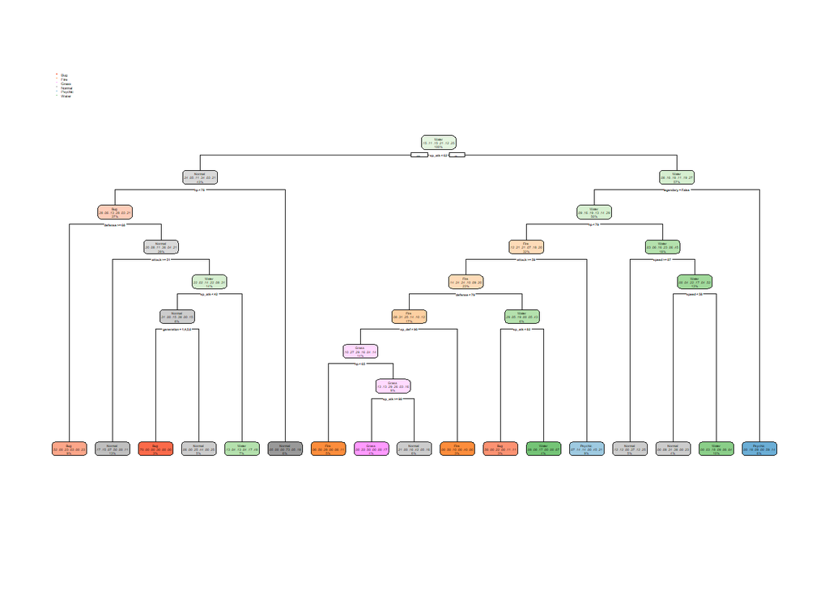

```r
#visualizing the tree
class_tree_final_fit %>%
  extract_fit_engine() %>%
  rpart.plot()
```

### Exercise 5

```r
#model
rf_spec <- rand_forest(mtry = tune(), trees = tune(), min_n = tune()) %>%
  set_engine("ranger", importance = "impurity") %>%
  set_mode("classification")

p_grid <- grid_regular(mtry(range = c(1,8)),trees(range = c(100,500)),
                       min_n(range = c(1,10)), levels = 8)

#workflow
rf_tree_wf <- workflow() %>%
  add_model(rf_spec) %>%
  add_formula(type_1 ~ legendary + generation + sp_atk + attack + speed +
                defense + hp + sp_def)
```

The mtry parameter allows for a random selection of predictor variables (and is therefore dependent on the number of columns), trees specifies the number of decision trees to be built, and min_m defines the minimum number of data points on node or decision point, that will be required to split the node further. The mtry parameter can’t be less than 1 since that’s the minimum number of predictors needed for the model to run, and not more than 8 as our recipe defines a maximum of 8 predictor variables. Setting mtry to 8 would test a model similar to the one we’ve tested above with all of the predictor variables being used in the tree-based model (which may yield redundancies).

### Exercise 6

```r
tune_param <- tune_grid(
  rf_tree_wf,
  resamples = df_fold,
  grid = p_grid,
  metrics = metric_set(roc_auc),
  control = control_grid(verbose = T)
)
```

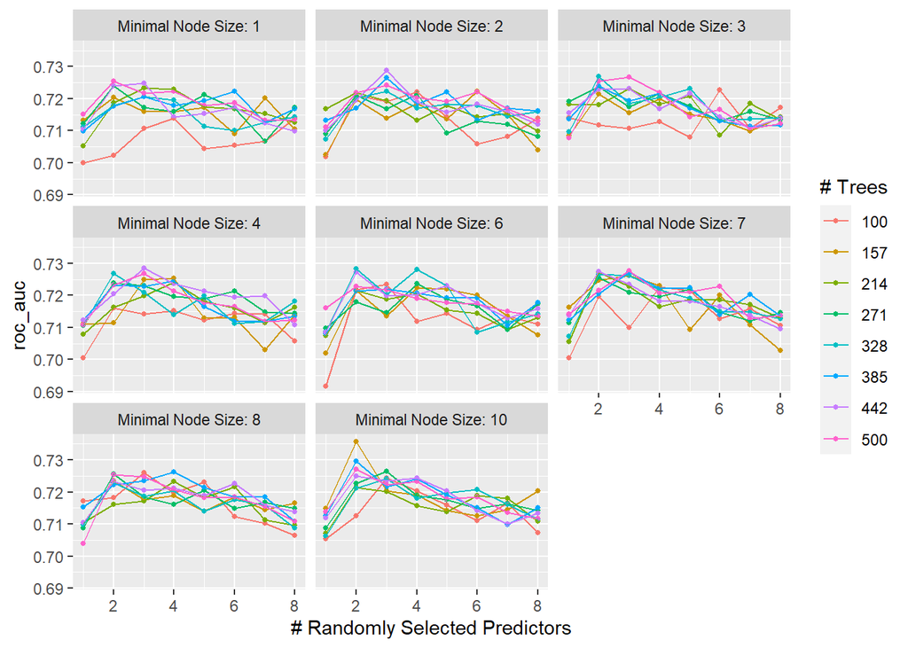

```r
autoplot(tune_param)
```

### Exercise 7

```r
tune_param %>%
  collect_metrics() %>%
  arrange(mean)
```

```
## # A tibble: 512 × 9
##     mtry trees min_n .metric .estimator  mean     n std_err .config
##    <int> <int> <int> <chr>   <chr>      <dbl> <int>   <dbl> <chr>
##  1     1   100     6 roc_auc hand_till  0.692     5  0.0239 Preprocessor1_Model…
##  2     1   100     1 roc_auc hand_till  0.700     5  0.0191 Preprocessor1_Model…
##  3     1   100     7 roc_auc hand_till  0.700     5  0.0228 Preprocessor1_Model…
##  4     1   100     4 roc_auc hand_till  0.700     5  0.0183 Preprocessor1_Model…
##  5     1   100     2 roc_auc hand_till  0.702     5  0.0193 Preprocessor1_Model…
##  6     1   157     6 roc_auc hand_till  0.702     5  0.0240 Preprocessor1_Model…
##  7     2   100     1 roc_auc hand_till  0.702     5  0.0172 Preprocessor1_Model…
##  8     1   157     2 roc_auc hand_till  0.703     5  0.0180 Preprocessor1_Model…
##  9     8   157     7 roc_auc hand_till  0.703     5  0.0196 Preprocessor1_Model…
## 10     7   157     4 roc_auc hand_till  0.703     5  0.0171 Preprocessor1_Model…
## # … with 502 more rows
```

```r
best_params <- select_best(tune_param, metric = "roc_auc")
best_params
```

```
## # A tibble: 1 × 4
##    mtry trees min_n .config
##   <int> <int> <int> <chr>
## 1     2   157    10 Preprocessor1_Model458
```

The ROC AUC of the best model is 0.73.

### Exercise 8

```r
#finalizing workflow and fit
rf_tree_final <- finalize_workflow(rf_tree_wf, best_params)
rf_tree_final_fit <- fit(rf_tree_final, data = df_train)
rf_tree_final_fit
```

```
## ══ Workflow [trained] ══════════════════════════════════════════════════════════
## Preprocessor: Formula
## Model: rand_forest()
##
## ── Preprocessor ────────────────────────────────────────────────────────────────
## type_1 ~ legendary + generation + sp_atk + attack + speed + defense +
##     hp + sp_def
##
## ── Model ───────────────────────────────────────────────────────────────────────
## Ranger result
##
## Call:
##  ranger::ranger(x = maybe_data_frame(x), y = y, mtry = min_cols(~2L,      x), num.trees = ~157L, min.node.size = min_rows(~10L, x),      importance = ~"impurity", num.threads = 1, verbose = FALSE,      seed = sample.int(10^5, 1), probability = TRUE)
##
## Type:                             Probability estimation
## Number of trees:                  157
## Sample size:                      341
## Number of independent variables:  8
## Mtry:                             2
## Target node size:                 10
## Variable importance mode:         impurity
## Splitrule:                        gini
## OOB prediction error (Brier s.):  0.5659893
```

```r
augment(rf_tree_final_fit, new_data = df_train) %>%
  roc_auc(truth = type_1, estimate = .pred_Bug:.pred_Water)
```

```
## # A tibble: 1 × 3
##   .metric .estimator .estimate
##   <chr>   <chr>          <dbl>
## 1 roc_auc hand_till      0.997
```

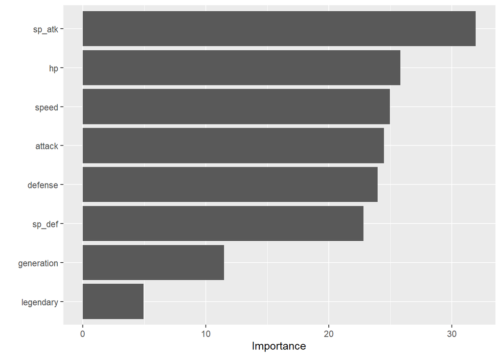

```r
rf_tree_final_fit %>%
  extract_fit_parsnip() %>%
  vip()
```

```r
df_train %>%
  group_by(type_1) %>%
  summarise(mean = mean(sp_atk), n =n())
```

```
## # A tibble: 6 × 3
##   type_1   mean     n
##   <fct>   <dbl> <int>
## 1 Bug      55.7    51
## 2 Fire     87.1    39
## 3 Grass    77.6    52
## 4 Normal   55.9    73
## 5 Psychic  99.9    42
## 6 Water    75.2    84
```

These results indicate that the special attack value is the most useful while legendary status is the least useful in predicting type of Pokemon. This is not entirely what would be expected since a pokemon’s legendary status would significantly help in streamlining the type of pokemon bu only if they are indeed legendary. The importance of the special attack makes intuitive sense since looking at these values by type, there does look to be some significant differences.

### Exercise 9

```r
#model
boost_spec <- boost_tree(trees = tune()) %>%
  set_engine("xgboost") %>%
  set_mode("classification")

#workflow
boost_wf <- workflow() %>%
  add_model(boost_spec) %>%
  add_formula(type_1 ~ legendary + generation + sp_atk + attack + speed +
                defense + hp + sp_def)

#parameter grid
set.seed(1212)
boost_grid <- grid_regular(trees(range = c(10,2000)), levels = 10)

#tuning
tune_boost <- tune_grid(
  boost_wf,
  resamples = df_fold,
  grid = boost_grid,
  metrics = metric_set(roc_auc),
  control = control_grid(verbose = T)
)
```

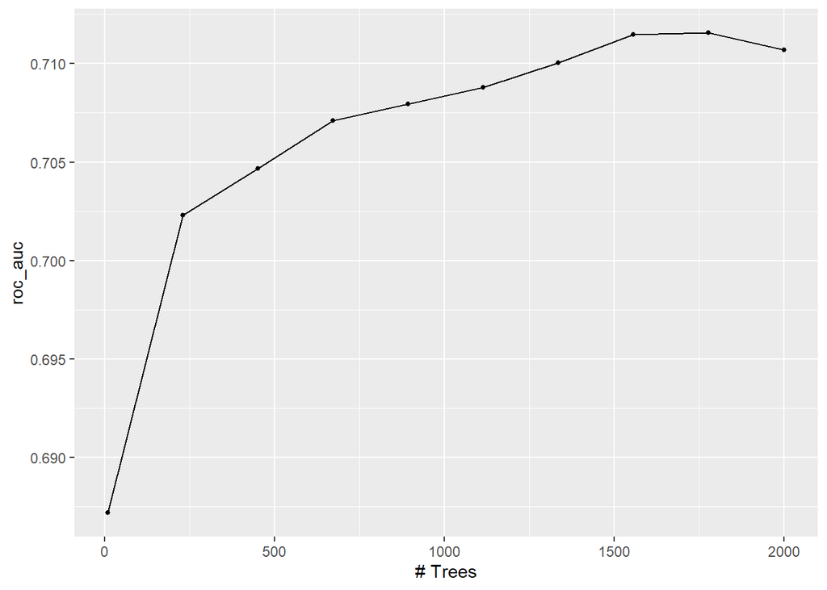

```r
#visual
autoplot(tune_boost)
```

```r
#best model
best_boost <- select_best(tune_boost, metric = "roc_auc")
best_boost
```

```
## # A tibble: 1 × 2
##   trees .config
##   <int> <chr>
## 1  1778 Preprocessor1_Model09
```

```r
boost_final <- finalize_workflow(boost_wf, best_boost)
boost_final_fit <- fit(boost_final, data = df_train)
boost_final_fit
```

```
## ══ Workflow [trained] ══════════════════════════════════════════════════════════
## Preprocessor: Formula
## Model: boost_tree()
##
## ── Preprocessor ────────────────────────────────────────────────────────────────
## type_1 ~ legendary + generation + sp_atk + attack + speed + defense +
##     hp + sp_def
##
## ── Model ───────────────────────────────────────────────────────────────────────
## ##### xgb.Booster
## raw: 8.8 Mb
## call:
##   xgboost::xgb.train(params = list(eta = 0.3, max_depth = 6, gamma = 0,
##     colsample_bytree = 1, colsample_bynode = 1, min_child_weight = 1,
##     subsample = 1), data = x$data, nrounds = 1778L, watchlist = x$watchlist,
##     verbose = 0, nthread = 1, objective = "multi:softprob", num_class = 6L)
## params (as set within xgb.train):
##   eta = "0.3", max_depth = "6", gamma = "0", colsample_bytree = "1", colsample_bynode = "1", min_child_weight = "1", subsample = "1", nthread = "1", objective = "multi:softprob", num_class = "6", validate_parameters = "TRUE"
## xgb.attributes:
##   niter
## callbacks:
##   cb.evaluation.log()
## # of features: 14
## niter: 1778
## nfeatures : 14
## evaluation_log:
##     iter training_mlogloss
##        1        1.48348110
##        2        1.27596114
## ---
##     1777        0.02561041
##     1778        0.02560885
```

```r
augment(boost_final_fit, new_data = df_train) %>%
  roc_auc(truth = type_1, estimate = .pred_Bug:.pred_Water)
```

```
## # A tibble: 1 × 3
##   .metric .estimator .estimate
##   <chr>   <chr>          <dbl>
## 1 roc_auc hand_till       1.00
```

```r
collect_metrics(tune_boost) %>% arrange(mean)
```

```
## # A tibble: 10 × 7
##    trees .metric .estimator  mean     n std_err .config
##    <int> <chr>   <chr>      <dbl> <int>   <dbl> <chr>
##  1    10 roc_auc hand_till  0.687     5  0.0222 Preprocessor1_Model01
##  2   231 roc_auc hand_till  0.702     5  0.0188 Preprocessor1_Model02
##  3   452 roc_auc hand_till  0.705     5  0.0173 Preprocessor1_Model03
##  4   673 roc_auc hand_till  0.707     5  0.0169 Preprocessor1_Model04
##  5   894 roc_auc hand_till  0.708     5  0.0171 Preprocessor1_Model05
##  6  1115 roc_auc hand_till  0.709     5  0.0172 Preprocessor1_Model06
##  7  1336 roc_auc hand_till  0.710     5  0.0170 Preprocessor1_Model07
##  8  2000 roc_auc hand_till  0.711     5  0.0165 Preprocessor1_Model10
##  9  1557 roc_auc hand_till  0.711     5  0.0167 Preprocessor1_Model08
## 10  1778 roc_auc hand_till  0.712     5  0.0166 Preprocessor1_Model09
```

We see here that the ROC AUC value increases as the number of trees increases. However, setting trees too high can lead to over fitting issues. The ROC AUC value of the best performing model is 0.71.

### Exercise 10

```r
model_types = c("pruned tree","random forest","boosted tree")
tune_results = lst(tune_res, tune_param, tune_boost)
best_model = lst(best_penalty, best_params, best_boost)
final_models = lst(class_tree_final_fit, rf_tree_final_fit, boost_final_fit)

rocauc = c()

for (idx in 1:length(tune_results)){
  performance_tbl <- collect_metrics(tune_results[[idx]]) %>% arrange(mean)
  best_rocauc <- (filter(performance_tbl, .config == best_model[[idx]]['1', '.config'][[1]]))$mean
  rocauc <- c(rocauc,best_rocauc)
}

# put the model types and their ROC AUC's into one table
combined <- as_tibble(cbind(model_types,rocauc))
combined
```

```
## # A tibble: 3 × 2
##   model_types   rocauc
##   <chr>         <chr>
## 1 pruned tree   0.638371012858771
## 2 random forest 0.735783961977047
## 3 boosted tree  0.711568921138244
```

```r
# using the table of rocaucs, find the model type with the best roc auc,
# and set "best_model" equal to that model's final workflow
best_model <- final_models[which.max(combined$rocauc)]
best_model
```

```
## $rf_tree_final_fit
## ══ Workflow [trained] ══════════════════════════════════════════════════════════
## Preprocessor: Formula
## Model: rand_forest()
##
## ── Preprocessor ────────────────────────────────────────────────────────────────
## type_1 ~ legendary + generation + sp_atk + attack + speed + defense +
##     hp + sp_def
##
## ── Model ───────────────────────────────────────────────────────────────────────
## Ranger result
##
## Call:
##  ranger::ranger(x = maybe_data_frame(x), y = y, mtry = min_cols(~2L,      x), num.trees = ~157L, min.node.size = min_rows(~10L, x),      importance = ~"impurity", num.threads = 1, verbose = FALSE,      seed = sample.int(10^5, 1), probability = TRUE)
##
## Type:                             Probability estimation
## Number of trees:                  157
## Sample size:                      341
## Number of independent variables:  8
## Mtry:                             2
## Target node size:                 10
## Variable importance mode:         impurity
## Splitrule:                        gini
## OOB prediction error (Brier s.):  0.5659893
```

```r
#re-fit on test data
test_mod <- augment(best_model[[1]], new_data = df_test)
test_mod
```

```
## # A tibble: 117 × 20
##        x name       type_1 type_2 total    hp attack defense sp_atk sp_def speed
##    <int> <chr>      <fct>  <chr>  <int> <int>  <int>   <int>  <int>  <int> <int>
##  1     3 VenusaurM… Grass  "Pois…   625    80    100     123    122    120    80
##  2    10 Caterpie   Bug    ""       195    45     30      35     20     20    45
##  3    14 Kakuna     Bug    "Pois…   205    45     25      50     25     25    35
##  4    15 BeedrillM… Bug    "Pois…   495    65    150      40     15     80   145
##  5    19 Rattata    Normal ""       253    30     56      35     25     35    72
##  6    60 Poliwag    Water  ""       300    40     50      40     40     40    90
##  7    63 Abra       Psych… ""       310    25     20      15    105     55    90
##  8    65 Alakazam   Psych… ""       500    55     50      45    135     95   120
##  9    73 Tentacruel Water  "Pois…   515    80     70      65     80    120   100
## 10    78 Rapidash   Fire   ""       500    65    100      70     80     80   105
## # … with 107 more rows, and 9 more variables: generation <fct>,
## #   legendary <fct>, .pred_class <fct>, .pred_Bug <dbl>, .pred_Fire <dbl>,
## #   .pred_Grass <dbl>, .pred_Normal <dbl>, .pred_Psychic <dbl>,
## #   .pred_Water <dbl>
```

```r
#ROC_AUC
test_mod %>%
  roc_auc(truth = type_1, estimate = .pred_Bug:.pred_Water)
```

```
## # A tibble: 1 × 3
##   .metric .estimator .estimate
##   <chr>   <chr>          <dbl>
## 1 roc_auc hand_till      0.689
```

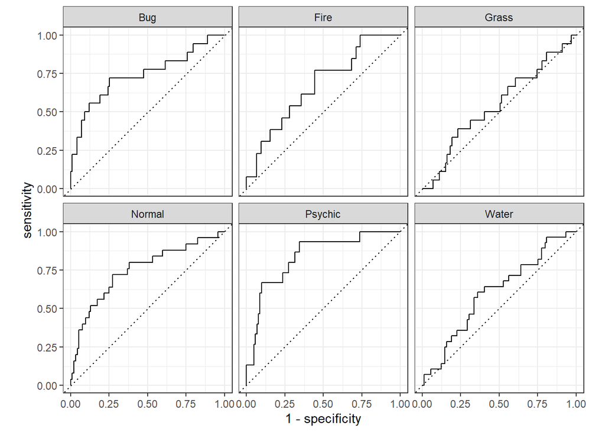

```r
#ROC curves
test_mod %>%
  roc_curve(truth = type_1, estimate = .pred_Bug:.pred_Water) %>%
  autoplot()
```

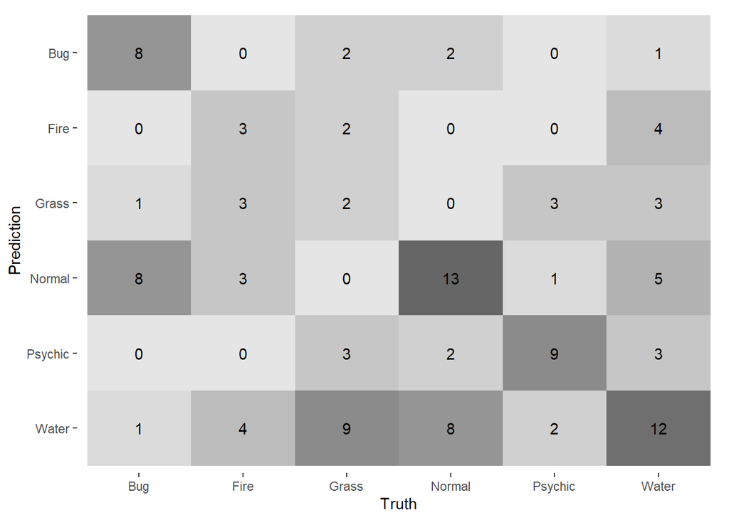

```r
#heatmap
test_mod %>%
  conf_mat(truth = type_1, estimate = .pred_class) %>%
  autoplot(type = "heatmap")
```

### Exercise 11

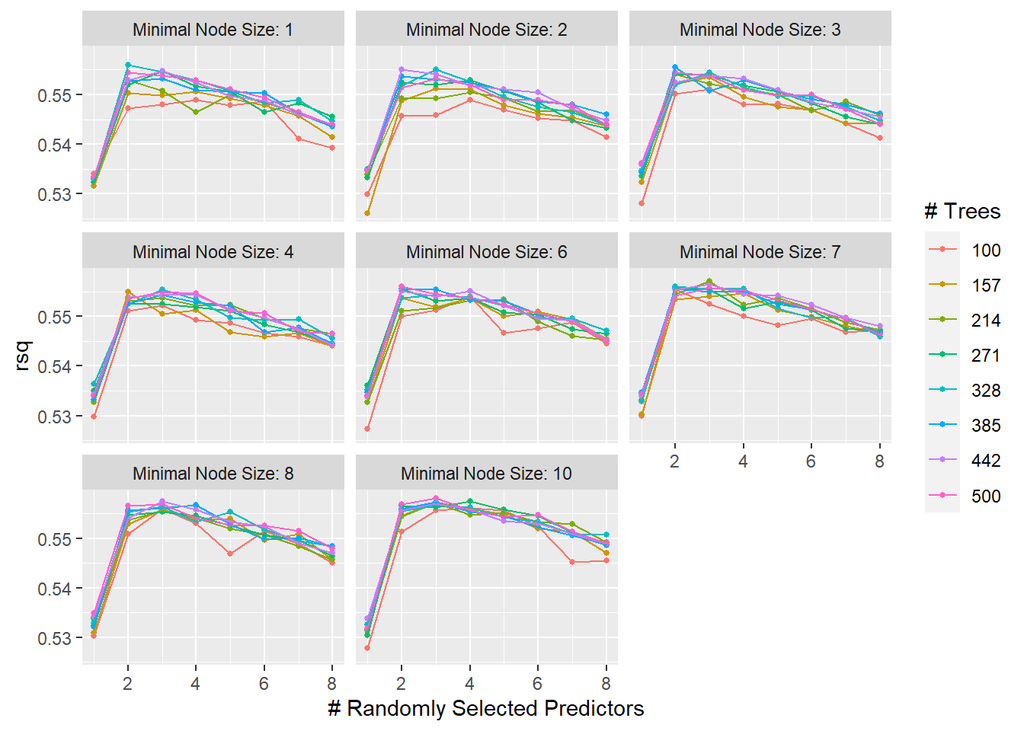

```r
#setup
data_input <- read.csv("abalone.csv")
data <- as_tibble(data_input) %>%
  mutate(age = rings+1.5)  %>%
  mutate(type = factor(type))  %>%
  select(-rings)

#splitting data
set.seed(3435)
data_split <- initial_split(data, strata = "age")

data_train <- training(data_split)
data_test <- testing(data_split)

#model
abalone_spec <- rand_forest(mtry = tune(), trees = tune(), min_n = tune()) %>%
  set_engine("ranger", importance = "impurity") %>%
  set_mode("regression")

#tuning grid
ab_grid <- grid_regular(mtry(range = c(1,8)),trees(range = c(100,500)),
                       min_n(range = c(1,10)), levels = 8)

#workflow
abalone_wf <- workflow() %>%
  add_model(abalone_spec) %>%
  add_formula(age ~ longest_shell + diameter + height + whole_weight + shucked_weight +
                viscera_weight + shell_weight + type)

#v-fold for cross-alidation
data_fold <- vfold_cv(data_train, v=5, strata = "age")

#tuning
tune_abalone <- tune_grid(
  abalone_wf,
  resamples = data_fold,
  grid = ab_grid,
  metrics = metric_set(rsq),
  control = control_grid(verbose = T)
)

#visualizing
autoplot(tune_abalone)
```

```r
#best model
ab_best <- select_best(tune_abalone, metric = "rsq")

#finalizing workflow
ab_final <- finalize_workflow(abalone_wf, ab_best)
ab_final_fit <- fit(ab_final, data = data_train)
ab_final_fit
```

```
## ══ Workflow [trained] ══════════════════════════════════════════════════════════
## Preprocessor: Formula
## Model: rand_forest()
##
## ── Preprocessor ────────────────────────────────────────────────────────────────
## age ~ longest_shell + diameter + height + whole_weight + shucked_weight +
##     viscera_weight + shell_weight + type
##
## ── Model ───────────────────────────────────────────────────────────────────────
## Ranger result
##
## Call:
##  ranger::ranger(x = maybe_data_frame(x), y = y, mtry = min_cols(~3L,      x), num.trees = ~500L, min.node.size = min_rows(~10L, x),      importance = ~"impurity", num.threads = 1, verbose = FALSE,      seed = sample.int(10^5, 1))
##
## Type:                             Regression
## Number of trees:                  500
## Sample size:                      3131
## Number of independent variables:  8
## Mtry:                             3
## Target node size:                 10
## Variable importance mode:         impurity
## Splitrule:                        variance
## OOB prediction error (MSE):       4.508648
## R squared (OOB):                  0.5614716
```

```r
#rmse for training data
augment(ab_final_fit, new_data = data_train) %>%
  rmse(truth = age, estimate = .pred)
```

```
## # A tibble: 1 × 3
##   .metric .estimator .estimate
##   <chr>   <chr>          <dbl>
## 1 rmse    standard        1.19
```

```r
#rsq for training
augment(ab_final_fit, new_data = data_train) %>%
  rsq(truth = age, estimate = .pred)
```

```
## # A tibble: 1 × 3
##   .metric .estimator .estimate
##   <chr>   <chr>          <dbl>
## 1 rsq     standard       0.880
```

```r
#rmse for testing data
augment(ab_final_fit, new_data = data_test) %>%
  rmse(truth = age, estimate = .pred)
```

```
## # A tibble: 1 × 3
##   .metric .estimator .estimate
##   <chr>   <chr>          <dbl>
## 1 rmse    standard        2.20
```

```r
#rsq for testing
augment(ab_final_fit, new_data = data_test) %>%
  rsq(truth = age, estimate = .pred)
```

```
## # A tibble: 1 × 3
##   .metric .estimator .estimate
##   <chr>   <chr>          <dbl>
## 1 rsq     standard       0.549
```

```r
collect_metrics(tune_abalone) %>% arrange(mean)
```

```
## # A tibble: 512 × 9
##     mtry trees min_n .metric .estimator  mean     n std_err .config
##    <int> <int> <int> <chr>   <chr>      <dbl> <int>   <dbl> <chr>
##  1     1   157     2 rsq     standard   0.526     5  0.0113 Preprocessor1_Model…
##  2     1   100     6 rsq     standard   0.527     5  0.0142 Preprocessor1_Model…
##  3     1   100    10 rsq     standard   0.528     5  0.0118 Preprocessor1_Model…
##  4     1   100     3 rsq     standard   0.528     5  0.0138 Preprocessor1_Model…
##  5     1   100     4 rsq     standard   0.530     5  0.0139 Preprocessor1_Model…
##  6     1   100     2 rsq     standard   0.530     5  0.0108 Preprocessor1_Model…
##  7     1   100     7 rsq     standard   0.530     5  0.0110 Preprocessor1_Model…
##  8     1   100     8 rsq     standard   0.530     5  0.0145 Preprocessor1_Model…
##  9     1   157     7 rsq     standard   0.530     5  0.0142 Preprocessor1_Model…
## 10     1   271    10 rsq     standard   0.530     5  0.0114 Preprocessor1_Model…
## # … with 502 more rows
```